# COVID-19 Hackathon / Containment measures effectiveness / Luca Ferrari

*Please consider that the following analysis has been conducted with data updated to* *April 3, 2020* .

## Problem Definition / Objective

**COVID-19** is spreading around the world at a fast pace.  
Data analysis is required to get a sense of the pandemic and assess the effectiveness of the containment measures.  
This analysis provide a new way of visualizing the growth data and tries to estimate how the different italian goverment containment measures impacted on the actual virus growth in Italy.

## Pre-processing

A great dataset is provided to carry out the analysis, however some pre-processing is required.  
Dataset used: https://github.com/CSSEGISandData/COVID-19

```python
import pandas as pd
import numpy as np
```

```python
# Time series data (ts)
ts = pd.read_csv('time_series_covid19_confirmed_global.csv')
```

```python
ts.head()
```

|  | Province/State | Country/Region | Lat | Long | 1/22/20 | 1/23/20 | 1/24/20 | 1/25/20 | 1/26/20 | 1/27/20 | ... | 3/25/20 | 3/26/20 | 3/27/20 | 3/28/20 | 3/29/20 | 3/30/20 | 3/31/20 | 4/1/20 | 4/2/20 | 4/3/20 |
| --- | --- | --- | --- | --- | --- | --- | --- | --- | --- | --- | --- | --- | --- | --- | --- | --- | --- | --- | --- | --- | --- |
| 0 | NaN | Afghanistan | 33.0000 | 65.0000 | 0 | 0 | 0 | 0 | 0 | 0 | ... | 84 | 94 | 110 | 110 | 120 | 170 | 174 | 237 | 273 | 281 |
| 1 | NaN | Albania | 41.1533 | 20.1683 | 0 | 0 | 0 | 0 | 0 | 0 | ... | 146 | 174 | 186 | 197 | 212 | 223 | 243 | 259 | 277 | 304 |
| 2 | NaN | Algeria | 28.0339 | 1.6596 | 0 | 0 | 0 | 0 | 0 | 0 | ... | 302 | 367 | 409 | 454 | 511 | 584 | 716 | 847 | 986 | 1171 |
| 3 | NaN | Andorra | 42.5063 | 1.5218 | 0 | 0 | 0 | 0 | 0 | 0 | ... | 188 | 224 | 267 | 308 | 334 | 370 | 376 | 390 | 428 | 439 |
| 4 | NaN | Angola | -11.2027 | 17.8739 | 0 | 0 | 0 | 0 | 0 | 0 | ... | 3 | 4 | 4 | 5 | 7 | 7 | 7 | 8 | 8 | 8 |

5 rows × 77 columns

Let's drop everything is not needed for the analysis

```python
del ts['Province/State']
del ts['Lat']
del ts['Long']
```

We will take in account just the most representative nations that already had tackled the virus in some way.  
Let's also transform the data so we have on one column the date and in another one the total number of cases until that exact day (*cnt*).  
China ts needs some further pre-processing because the dataset provide provinces data and we need the cumulative count.

```python
# Italian time serie
its = ts[ts['Country/Region'] == 'Italy']
del its['Country/Region']
its = pd.melt(its)
its = its.rename(columns = {'variable':'date','value':'cnt'})
date = pd.to_datetime(its.date)
its.date = date

# Chinese time serie
cts = ts[ts['Country/Region'] == 'China']
cts = cts.groupby(['Country/Region']).sum()
cts = pd.melt(cts)
cts = cts.rename(columns = {'variable':'date','value':'cnt'})
date = pd.to_datetime(cts.date)
cts.date = date

# US time serie
uts = ts[ts['Country/Region'] == 'US']
del uts['Country/Region']
uts = pd.melt(uts)
uts = uts.rename(columns = {'variable':'date','value':'cnt'})
date = pd.to_datetime(uts.date)
uts.date = date

# South korean time serie
kts = ts[ts['Country/Region'] == 'Korea, South']
del kts['Country/Region']
kts = pd.melt(kts)
kts = kts.rename(columns = {'variable':'date','value':'cnt'})
date = pd.to_datetime(kts.date)
kts.date = date
```

```python
cts.head()
```

|  | date | cnt |
| --- | --- | --- |
| 0 | 2020-01-22 | 548 |
| 1 | 2020-01-23 | 643 |
| 2 | 2020-01-24 | 920 |
| 3 | 2020-01-25 | 1406 |
| 4 | 2020-01-26 | 2075 |

## Data exploration

```python
import matplotlib
import matplotlib.pyplot as plt
```

First of all we will concentrate on Italy.  
Let's visualize the number of total cases against time.

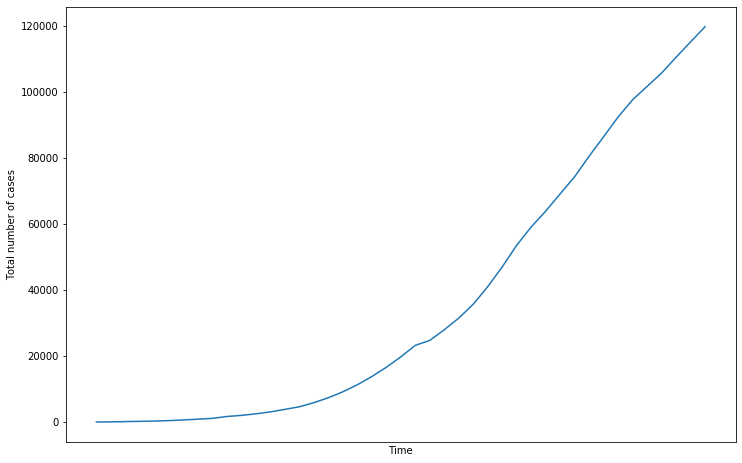

```python
fig, ax = plt.subplots(figsize=(12,8))

ax.plot(its.date,its.cnt)

ax.set(xlabel='Time',ylabel='Total number of cases')

plt.tick_params(
    axis='x',
    which='both',
    bottom=False,
    top=False,
    labelbottom=False)

plt.show()
```

Just taking a quick glance at the plot we can immediately recognize and exponential growth. However, a better representation of the growth will be given by a sigmoid curve which flattens out at some point (there are no more people to infect).

```python
from IPython.display import HTML
HTML('<iframe width="768" height="432" src="https://www.youtube.com/embed/Kas0tIxDvrg?start=287" frameborder="0" allow="encrypted-media; picture-in-picture" allowfullscreen></iframe>')
```

[video not shown]

As greatly explained in this video, the exponential growth and logit growth are pretty much the same until we get to the **Inflection point** in which the logistic starts to curve downward.

*How do we know when we reach the inflection point?*

Some further processing and analysis is required.

As I read in different articles (one of them being: https://shorturl.at/ewV78) one important number to compute is R0 which is the average number of secondary infection and if that is < 1 it means that the epidemic can be contained.

R0 can be computed by $\frac{new cases}{total cases}$, so we need to calculate the number of new cases.

```python
its['new_cases'] = its.cnt.diff().fillna(0)
cts['new_cases'] = cts.cnt.diff().fillna(0)
uts['new_cases'] = uts.cnt.diff().fillna(0)
kts['new_cases'] = kts.cnt.diff().fillna(0)
```

Let's take into account the data relative to the date since the number of new cases is significantly different then 0.

```python
its = its[its.date > '2020-02-20']
```

```python
its.head(30)
```

|  | date | cnt | new_cases |
| --- | --- | --- | --- |
| 30 | 2020-02-21 | 20 | 17.0 |
| 31 | 2020-02-22 | 62 | 42.0 |
| 32 | 2020-02-23 | 155 | 93.0 |
| 33 | 2020-02-24 | 229 | 74.0 |
| 34 | 2020-02-25 | 322 | 93.0 |
| 35 | 2020-02-26 | 453 | 131.0 |
| 36 | 2020-02-27 | 655 | 202.0 |
| 37 | 2020-02-28 | 888 | 233.0 |
| 38 | 2020-02-29 | 1128 | 240.0 |
| 39 | 2020-03-01 | 1694 | 566.0 |
| 40 | 2020-03-02 | 2036 | 342.0 |
| 41 | 2020-03-03 | 2502 | 466.0 |
| 42 | 2020-03-04 | 3089 | 587.0 |
| 43 | 2020-03-05 | 3858 | 769.0 |
| 44 | 2020-03-06 | 4636 | 778.0 |
| 45 | 2020-03-07 | 5883 | 1247.0 |
| 46 | 2020-03-08 | 7375 | 1492.0 |
| 47 | 2020-03-09 | 9172 | 1797.0 |
| 48 | 2020-03-10 | 10149 | 977.0 |
| 49 | 2020-03-11 | 12462 | 2313.0 |
| 50 | 2020-03-12 | 12462 | 0.0 |
| 51 | 2020-03-13 | 17660 | 5198.0 |
| 52 | 2020-03-14 | 21157 | 3497.0 |
| 53 | 2020-03-15 | 24747 | 3590.0 |
| 54 | 2020-03-16 | 27980 | 3233.0 |
| 55 | 2020-03-17 | 31506 | 3526.0 |
| 56 | 2020-03-18 | 35713 | 4207.0 |
| 57 | 2020-03-19 | 41035 | 5322.0 |
| 58 | 2020-03-20 | 47021 | 5986.0 |
| 59 | 2020-03-21 | 53578 | 6557.0 |

By visually inspecting the data we can notice that at line **50** something is wrong.  
It's very unlikely that in that exact day there were no new cases.That is probably due to the fact that the number of cases is not correctly reported, so we need to take care of it.  
Since the growth of the number of cases in time is basically monotonous we can safely interpolate data in the time window between 9/03 and 14/03 to provide a more realistic estimation of the growth.

```python
its = its.reset_index()
del its['index']
```

```python
its.iloc[17:23,2]
```

```
17    1797.0
18     977.0
19    2313.0
20       0.0
21    5198.0
22    3497.0
Name: new_cases, dtype: float64
```

The first and the last values are Ok.  
We need to transform the values in between.

```python
tmp = [1797.0,np.nan,np.nan,np.nan,np.nan,3497]
df = pd.DataFrame(tmp)
tmp = df.interpolate(method = 'linear')
tmp_sum = tmp
tmp = tmp.to_numpy()
```

```python
its.iloc[17:23,2] = tmp
```

What we have is just a simple estimate but that is much more realistic then the original data. Let's do the same thing for the number of total cases.

```python
its.iloc[17:23,1]
```

```
17     9172
18    10149
19    12462
20    12462
21    17660
22    21157
Name: cnt, dtype: int64
```

```python
tmp_sum = tmp_sum.cumsum()
tmp_sum = tmp_sum.to_numpy()
```

```python
its.iloc[17:23,1] = its.iloc[16,1] + tmp_sum
```

Let's replot the data. We should notice that the weird step when cnt~18000 is present no more.

```python
its_p = its.copy()
```

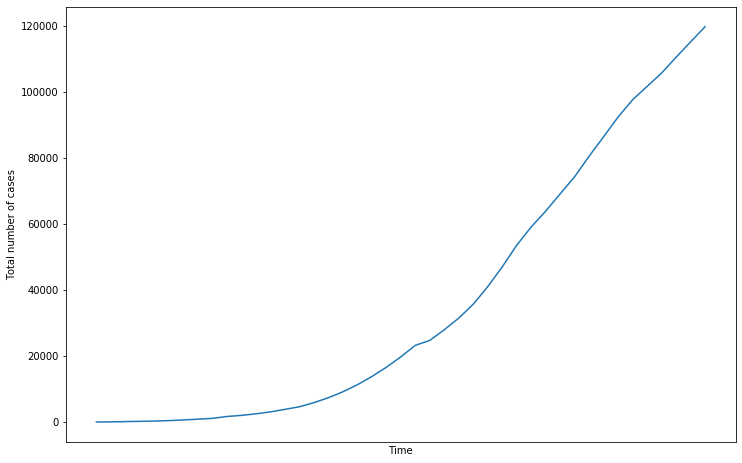

```python
fig, ax = plt.subplots(figsize=(12,8))

ax.plot(its.date,its.cnt)

ax.set(xlabel='Time',ylabel='Total number of cases')

plt.tick_params(
    axis='x',
    which='both',
    bottom=False,
    top=False,
    labelbottom=False)

plt.show()
```

Let's plot also the number of new cases against time.

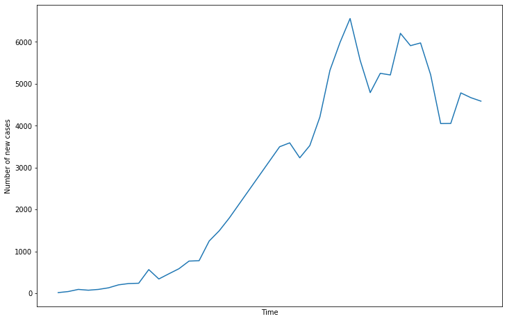

```python
fig, ax = plt.subplots(figsize=(12,8))

ax.plot(its.date,its.new_cases)

ax.set(xlabel='Time',ylabel='Number of new cases')

plt.tick_params(
    axis='x',
    which='both',
    bottom=False,
    top=False,
    labelbottom=False)

plt.show()
```

As we saw before, the data follows an (almost) exponential growth, and more interestingly there's a linear realtionship between the number of new cases and the total number of cases.

Let's plot the data with a log scale to actually see the relationship.

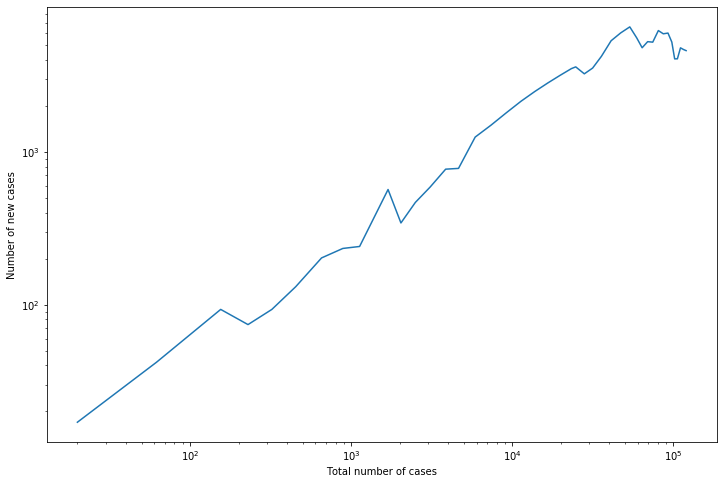

```python
fig, ax = plt.subplots(figsize=(12,8))

ax.loglog(its.cnt,its.new_cases)

ax.set(xlabel='Total number of cases',ylabel='Number of new cases')

plt.show()
```

The slope basically tells us the growth rate of the number of cases.  
That information can be exploited to provide insightful answers to different questions:

### 1. How do I recognize that exponential growth is ending?

If the line starts pointing downwards when a certain total number of cases is reached it means that R0 is getting lower and so there will be less and less new cases which obviously means that the exponential growth is ending (sigmoid curve flattening).

We can easily see it if we plot the chinese data.  
As we all know, China has already finished its quarantine, as reported by medias, and so we can se the effect of that in the growth of the number of the new cases.

```python
cts = cts[cts.date > '2020-01-22']
```

Since chinese data is really variable, some filtering is needed.  
To do that we can apply a moving average with a 5 days window.

```python
# Averaged China cnt
avg_c_cnt = cts.cnt.rolling(window = 5).mean()

# Averaged China new cases
avg_c_new_cases = cts.new_cases.rolling(window = 5).mean()
```

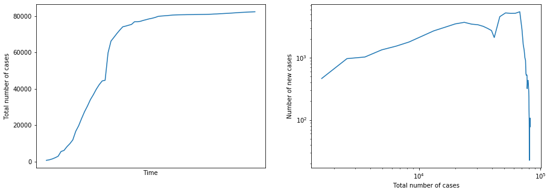

```python
f = plt.figure(figsize = (15,5))

plt.subplot(1,2,1)
plt.plot(cts.date,cts.cnt)
plt.xlabel('Time')
plt.ylabel('Total number of cases')

plt.tick_params(
    axis='x',
    which='both',
    bottom=False,
    top=False,
    labelbottom=False)

plt.subplot(1,2,2)
plt.loglog(avg_c_cnt,avg_c_new_cases)
plt.xlabel('Total number of cases')
plt.ylabel('Number of new cases')

plt.show()
```

On the right side we can see how the growth rate decreased after reaching a certain total number of cases and on the left side how the exponential growth in time started to take the sigmoid curve look.

### Italy

Going back to the italian case we can see that in the top right end of the curve there's an inflection. That demonstrates that we are starting to see the effects of the quarantine effort.  
*Notice that we wouldn't have acknowledged these effects if we just looked at the exponential curve of the total number of cases against time!*

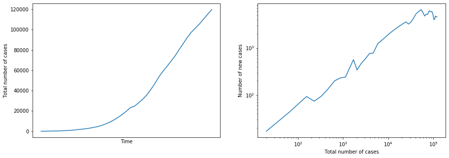

```python
f = plt.figure(figsize = (15,5))

plt.subplot(1,2,1)
plt.plot(its.date,its.cnt)
plt.xlabel('Time')
plt.ylabel('Total number of cases')

plt.tick_params(
    axis='x',
    which='both',
    bottom=False,
    top=False,
    labelbottom=False)

plt.subplot(1,2,2)
plt.loglog(its.cnt,its.new_cases)
plt.xlabel('Total number of cases')
plt.ylabel('Number of new cases')

plt.show()
```

### 2. Do the growth rates of the number of cases differ between nations?

To verify if the growth rates of the number of cases differ between nations we need to evaluate the different R0 and then compare them.  
Since this report part is all about visualization and inferring new information just by looking at the data, we can simply plot the different growth rates and esitimate the differences without actually computing anything.  
Similar growth rates will have approximately the same slope so we can verify that very quickly.

To reduce the variation we can apply the same technique as before and filter the new cases and the cnt date with a moving average.

```python
kts = kts[kts.date > '2020-02-19']
uts = uts[uts.date > '2020-02-25']
```

```python
# Averaged cnt
its['avg_cnt'] = its.cnt.rolling(window = 5).mean()
cts['avg_cnt'] = cts.cnt.rolling(window = 5).mean()
uts['avg_cnt'] = uts.cnt.rolling(window = 5).mean()
kts['avg_cnt'] = kts.cnt.rolling(window = 5).mean()

# Averaged new_cases
its['avg_new_cases'] = its.new_cases.rolling(window = 5).mean()
cts['avg_new_cases'] = cts.new_cases.rolling(window = 5).mean()
uts['avg_new_cases'] = uts.new_cases.rolling(window = 5).mean()
kts['avg_new_cases'] = kts.new_cases.rolling(window = 5).mean()
```

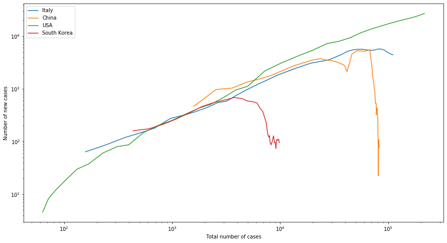

```python
fig, ax = plt.subplots(figsize=(15,8))

ax.loglog(its.avg_cnt,its.avg_new_cases)
ax.loglog(cts.avg_cnt,cts.avg_new_cases)
ax.loglog(uts.avg_cnt,uts.avg_new_cases)
ax.loglog(kts.avg_cnt,kts.avg_new_cases)

ax.set(xlabel='Total number of cases',ylabel='Number of new cases')

ax.legend(['Italy','China','USA','South Korea'])

plt.show()
```

Notice that we can see the effects of the quarantine in South Korea since the curve is pointing downwards while USA is still growing strongly.

## Containment measures effectiveness assessment

We discovered that by looking at the growth rate of the number of cases we can see the effects of the quarantine measures.  
What we want to do now is to see if we can predict the number of new cases given the total number of cases and the different cotainment measures.

Since we have the exact dates of the different containment measure adoptions, we will focus on the italian case.

```python
its.head(10)
```

|  | date | cnt | new_cases | avg_cnt | avg_new_cases |
| --- | --- | --- | --- | --- | --- |
| 0 | 2020-02-21 | 20.0 | 17.0 | NaN | NaN |
| 1 | 2020-02-22 | 62.0 | 42.0 | NaN | NaN |
| 2 | 2020-02-23 | 155.0 | 93.0 | NaN | NaN |
| 3 | 2020-02-24 | 229.0 | 74.0 | NaN | NaN |
| 4 | 2020-02-25 | 322.0 | 93.0 | 157.6 | 63.8 |
| 5 | 2020-02-26 | 453.0 | 131.0 | 244.2 | 86.6 |
| 6 | 2020-02-27 | 655.0 | 202.0 | 362.8 | 118.6 |
| 7 | 2020-02-28 | 888.0 | 233.0 | 509.4 | 146.6 |
| 8 | 2020-02-29 | 1128.0 | 240.0 | 689.2 | 179.8 |
| 9 | 2020-03-01 | 1694.0 | 566.0 | 963.6 | 274.4 |

First of all let's drop the two columns used for the visualization cause we do not need them now.

```python
del its['avg_cnt']
del its['avg_new_cases']
```

We need to create a structure that tells us for each day whether a certain containement measure was active or not.  
The different containment measures took into account are publicly available on the italian government website. (http://www.governo.it/it/approfondimento/coronavirus/13968)

There have been loads of decrees during quarantine, so we will take into account only the severe ones that can maybe predict the number of new cases.

```python
# Schools stop decree date
q0 = pd.Timestamp('2020-03-04')

# Commercial Activities stop decree date
q1 = pd.Timestamp('2020-03-07')

# Movement limitation and companies closure decree date
q2 = pd.Timestamp('2020-03-11')

# Social distancing decree date
q3 = pd.Timestamp('2020-03-22')
```

```python
s_schools = its['date'] > q0
s_commercial_act = its['date'] > q1
s_movement = its['date'] > q2
s_distancing = its['date'] > q3
```

```python
# Quarantine measures data
its_q = its.assign(s_schools = s_schools,
                   s_commercial_act = s_commercial_act,
                   s_movement = s_movement,
                   s_distancing = s_distancing
                   )
```

```python
its_q.head()
```

|  | date | cnt | new_cases | s_schools | s_commercial_act | s_movement | s_distancing |
| --- | --- | --- | --- | --- | --- | --- | --- |
| 0 | 2020-02-21 | 20.0 | 17.0 | False | False | False | False |
| 1 | 2020-02-22 | 62.0 | 42.0 | False | False | False | False |
| 2 | 2020-02-23 | 155.0 | 93.0 | False | False | False | False |
| 3 | 2020-02-24 | 229.0 | 74.0 | False | False | False | False |
| 4 | 2020-02-25 | 322.0 | 93.0 | False | False | False | False |

What we have now is a DataFrame that tells us which containment measures were active on a certain day.

Let's now remove the date and transform cnt and new_cases with a log transformation.

```python
its_q['log_cnt'] = np.log10(its_q.cnt)
its_q['log_new_cases'] = np.log10(its_q.new_cases)
del its_q['date']
del its_q['cnt']
del its_q['new_cases']
```

```python
its_q.head()
```

|  | s_schools | s_commercial_act | s_movement | s_distancing | log_cnt | log_new_cases |
| --- | --- | --- | --- | --- | --- | --- |
| 0 | False | False | False | False | 1.301030 | 1.230449 |
| 1 | False | False | False | False | 1.792392 | 1.623249 |
| 2 | False | False | False | False | 2.190332 | 1.968483 |
| 3 | False | False | False | False | 2.359835 | 1.869232 |
| 4 | False | False | False | False | 2.507856 | 1.968483 |

We can now standardize the data and make it suitable for further operations.

```python
from sklearn.preprocessing import scale
its_q_std = pd.DataFrame(scale(its_q), index=its_q.index, columns=its_q.columns)
```

Let's check out the correlation matrix

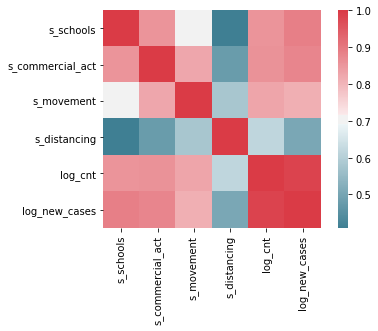

```python
import seaborn as sns
its_q_corr = its_q_std.corr()
sns.heatmap(its_q_corr, mask=np.zeros_like(its_q_corr, dtype=np.bool), cmap=sns.diverging_palette(220, 10, as_cmap=True),square=True)
```

We can try to predict the new number of cases, or better to see how the different containment measures impact on the growth rate using a simple linear regression model.

```python
# Features
X = its_q_std.loc[:,its_q_std.columns != 'log_new_cases']

# Target
Y = its_q_std.log_new_cases
```

```python
from sklearn.linear_model import LinearRegression
model = LinearRegression(fit_intercept = True)
model.fit(X,Y)
```

```
LinearRegression(copy_X=True, fit_intercept=True, n_jobs=None, normalize=False)
```

Since we just want to see how the different containement measures impact on the number of new cases we won't divide the dataset into Training set and Test set but we just fit the model and evaluate the different metrics.

```python
Y_pred = model.predict(X)
```

```python
import statsmodels.api as sm
x_train_sm = sm.add_constant(X)
model_sm=sm.OLS(Y, x_train_sm).fit()
model_sm.summary()
```

OLS Regression Results

| Dep. Variable: | log_new_cases | R-squared: | 0.989 |
| --- | --- | --- | --- |
| Model: | OLS | Adj. R-squared: | 0.987 |
| Method: | Least Squares | F-statistic: | 650.8 |
| Date: | Mon, 06 Apr 2020 | Prob (F-statistic): | 5.67e-35 |
| Time: | 09:41:08 | Log-Likelihood: | 35.480 |
| No. Observations: | 43 | AIC: | -58.96 |
| Df Residuals: | 37 | BIC: | -48.39 |
| Df Model: | 5 |  |  |
| Covariance Type: | nonrobust |  |  |

|  | coef | std err | t | P>\|t\| | [0.025 | 0.975] |
| --- | --- | --- | --- | --- | --- | --- |
| const | 4.094e-16 | 0.017 | 2.35e-14 | 1.000 | -0.035 | 0.035 |
| s_schools | 0.0677 | 0.040 | 1.693 | 0.099 | -0.013 | 0.149 |
| s_commercial_act | 0.0743 | 0.043 | 1.733 | 0.091 | -0.013 | 0.161 |
| s_movement | -0.0050 | 0.035 | -0.141 | 0.889 | -0.077 | 0.067 |
| s_distancing | -0.1446 | 0.024 | -6.139 | 0.000 | -0.192 | -0.097 |
| log_cnt | 0.9557 | 0.048 | 20.084 | 0.000 | 0.859 | 1.052 |

| Omnibus: | 0.509 | Durbin-Watson: | 1.359 |
| --- | --- | --- | --- |
| Prob(Omnibus): | 0.775 | Jarque-Bera (JB): | 0.518 |
| Skew: | 0.238 | Prob(JB): | 0.772 |
| Kurtosis: | 2.749 | Cond. No. | 6.54 |

Warnings:  
[1] Standard Errors assume that the covariance matrix of the errors is correctly specified.

### Comments

What we expected to find was:

- A large positive coefficient for **log_cnt** since, as we said earlier, there's a linear relationship between that and **log_new_cases**. This makes **log_cnt** a strong predictor and we can assess it by looking at the p-value which is 0.00.
- Negative coefficients for all the containment measures features. We obviously would expect a negative growth of the number of cases if quarantine measures are applied. However, what we actually got is a statistically significant negative coefficient just related to **social distancing** (p-value = 0.00). Moreover positive and almost statistically significant coeffiecients values were estimated for **s_schools** and **s_commercial_act**. Nevertheless those coefficients were almost 0 so they can't be taken into account as predictors.

Potential problems:

- We need to take into account that some measures are less strict then others and so the effect of these **measures is delayed in time**. This delay can't be properly detected by the model and it confuses measures with each others.
- **Multicollinearity**
- **Lack of data** of negative growth. It is possible that the model can't properly predict the falling of the number of new cases because we are in the beginning of the descent (Italy).

Let's try to manage the delay of the effect of the containment measures and re-train the model.

### Model 2 - delay management

To see the effects of the quarantine measures we probably need to compensate the real delay by adding a time offset to the days when those measures were instantiated.  
We can try to estimate the time offset based on how strict the actual measurement was and how many people were involved.

```python
from pandas.tseries.offsets import DateOffset

# Different time offsets based on the strentgh of the measure
q0 = q0 + DateOffset(days = 13)
q1 = q1 + DateOffset(days = 13)
q2 = q2 + DateOffset(days = 11)
q3 = q3 + DateOffset(days = 4)
```

```python
s_schools = its['date'] > q0
s_commercial_act = its['date'] > q1
s_movement = its['date'] > q2
s_distancing = its['date'] > q3
```

```python
# Quarantine measures data with delay
its_q_d = its.assign(s_schools = s_schools,
                     s_commercial_act = s_commercial_act,
                     s_movement = s_movement,
                     s_distancing = s_distancing
                    )
```

```python
its_q_d['log_cnt'] = np.log10(its_q_d.cnt)
its_q_d['log_new_cases'] = np.log10(its_q_d.new_cases)
del its_q_d['date']
del its_q_d['cnt']
del its_q_d['new_cases']
```

```python
# Standardize data
its_q_d_std = pd.DataFrame(scale(its_q_d), index=its_q_d.index, columns=its_q_d.columns)
```

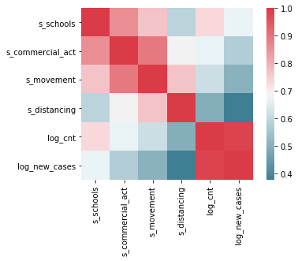

```python
# Correlation matrix
its_q_d_corr = its_q_d_std.corr()
sns.heatmap(its_q_d_corr, mask=np.zeros_like(its_q_d_corr, dtype=np.bool), cmap=sns.diverging_palette(220, 10, as_cmap=True),square=True)
```

Notice that now features are way less correlated to each other.

```python
# Features
X = its_q_d_std.loc[:,its_q_d_std.columns != 'log_new_cases']

# Target
Y = its_q_d_std.log_new_cases
```

```python
model = LinearRegression(fit_intercept = True)
model.fit(X,Y)
```

```
LinearRegression(copy_X=True, fit_intercept=True, n_jobs=None, normalize=False)
```

```python
Y_pred = model.predict(X)
```

```python
x_train_sm = sm.add_constant(X)
model_sm=sm.OLS(Y, x_train_sm).fit()
model_sm.summary()
```

OLS Regression Results

| Dep. Variable: | log_new_cases | R-squared: | 0.989 |
| --- | --- | --- | --- |
| Model: | OLS | Adj. R-squared: | 0.987 |
| Method: | Least Squares | F-statistic: | 643.8 |
| Date: | Mon, 06 Apr 2020 | Prob (F-statistic): | 6.91e-35 |
| Time: | 10:18:41 | Log-Likelihood: | 35.249 |
| No. Observations: | 43 | AIC: | -58.50 |
| Df Residuals: | 37 | BIC: | -47.93 |
| Df Model: | 5 |  |  |
| Covariance Type: | nonrobust |  |  |

|  | coef | std err | t | P>\|t\| | [0.025 | 0.975] |
| --- | --- | --- | --- | --- | --- | --- |
| const | 4.094e-16 | 0.018 | 2.34e-14 | 1.000 | -0.036 | 0.036 |
| s_schools | 0.0140 | 0.038 | 0.371 | 0.712 | -0.062 | 0.090 |
| s_commercial_act | -0.0227 | 0.049 | -0.461 | 0.647 | -0.122 | 0.077 |
| s_movement | -0.0866 | 0.045 | -1.938 | 0.060 | -0.177 | 0.004 |
| s_distancing | -0.0906 | 0.027 | -3.303 | 0.002 | -0.146 | -0.035 |
| log_cnt | 1.0878 | 0.026 | 41.871 | 0.000 | 1.035 | 1.140 |

| Omnibus: | 2.633 | Durbin-Watson: | 1.246 |
| --- | --- | --- | --- |
| Prob(Omnibus): | 0.268 | Jarque-Bera (JB): | 1.453 |
| Skew: | 0.095 | Prob(JB): | 0.484 |
| Kurtosis: | 2.120 | Cond. No. | 6.99 |

Warnings:  
[1] Standard Errors assume that the covariance matrix of the errors is correctly specified.

### Comments

The result of the analysis is closer to what we expected, however is possible that the result is distorted because of the wrong assumptions on the delayed effects of the quarantine measures, because of multicollinearity of data or as we said before, because of a lack of data on the descent phase.

The large value of R2 is probably due to the fact that basically all of the variability is explained by the **log_cnt** predictor.

## Conclusions

We saw that it is possible to assess the containment measures efficacy looking at the number of new cases against the number of total cases and we discovered that the virus basically spreads equally among all the different nations taken into account. It is very likely that it is possible to extend what we found to the entire world nations, however a more rigorous analysis has to be carried out.

More data is needed and further analysis have to be done in order to understand how the single different quarantine measures impact on the number of new cases, giving us the possibility to predict it and develop strategies to contain the epidemic.